# The Allure and Limitations of Productivity Metrics in AI

Author

Professor Barrington Ravenguard

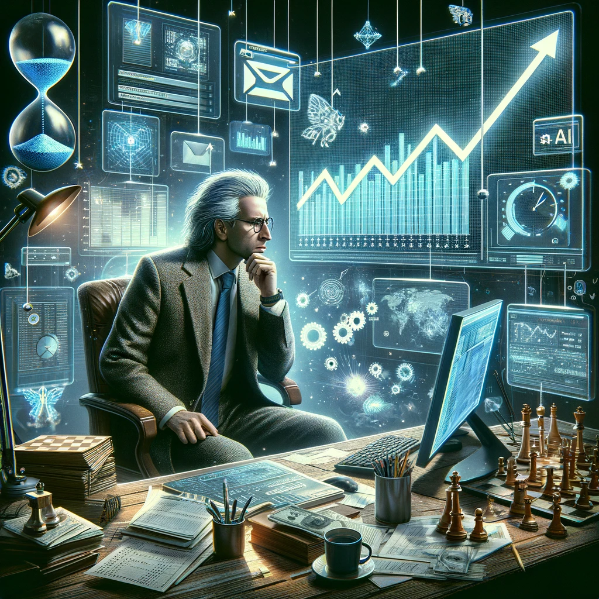

We love to measure productivity. As managers and analysts, quantifying output feels comforting - it gives us concrete data to make decisions with. However, when evaluating new technologies like algorithms and AI, our traditional productivity metrics often come up short (Wilson et al. 2021).

For example, a new predictive maintenance algorithm may slightly slow a production line. By traditional productivity measures focused on volume and speed, it scores poorly. But by reducing downstream disruptions and failures, it better optimises the entire supply chain - a benefit that standard metrics miss. As analysts at McKinsey have pointed out, new AI recruiting tools may take more upfront time to implement than prior systems (Bughin et al. 2021). But by surfacing better candidates, they drive dramatic improvements in quality and retention that pay dividends over years.

In short, multiple research studies have shown that applying conventional productivity lenses often underestimates the gains AI can drive (Agrawal et al. 2021). While efficiency benchmarks have their place, they insufficiently measure AI’s systemic, widespread improvements that raise overall performance. To capture its true value, productivity metrics must become more holistic. Rather than just simplistic speed and volume counts, we need multidimensional measures that account for enhanced decision making, reduced risk, higher quality, better experiences, and increased innovation, as researchers at Stanford have suggested (Cockburn et al. 2018).

Only with better metrics can we escape the illusion that algorithms and AI are merely automation tools (Wilson et al. 2021). In reality, their indirect, higher-order benefits make them drivers of progress unmatched by any productivity-enhancing technology we have adopted in decades. But we cannot manage and optimise what we do not measure. As stewards of progress, we must develop metrics as innovative and far-reaching as the technologies we aim to implement.

## References

Chui, Michael, Nicolaus Henke, and Mehdi Miremadi. “Most of AI’s business uses will be in two areas.” Harvard Business Review 12 (2018).

Wilson, H. James, Paul R. Daugherty, and Nicola Morini-Bianzino. “The jobs that artificial intelligence will create.” MIT Sloan Management Review 62.4 (2021): 14-16.

Bughin, Jacques, et al. “The promise and challenge of the age of artificial intelligence.” McKinsey Global Institute (2021).

Agrawal, Ajay, Joshua Gans, and Avi Goldfarb. Prediction machines: the simple economics of artificial intelligence. Harvard Business Press, 2021.

Cockburn, Iain M., Rebecca Henderson, and Scott Stern. “The impact of artificial intelligence on innovation.” The Economics of Artificial Intelligence: An Agenda. University of Chicago Press, 2018. 115-146.